# Wrangling Data ROCKS: Data Wrangling Tutorial

Michaline Becknell

## Introduction:

### This is a tutorial on data wrangling, the process of transforming raw, messy data into a clean and usable format suitable for modeling and visualization. We will be using fivethirtyeight’s ‘classic_rock_raw_data’ and ‘classic_rock_song_list’ datasets. The datasets feature similar information about 2,229 classic rock songs, with varibles like ‘song’ (title), ‘artist’ (name), ‘release_year’, and (radio) ‘callsign’. Our focus will be answering the question: what is the proportion of occurances of popularclassic rock songs by radio station? Let’s rock and roll!

- First let’s load in our packages. As you can see, there are helpful notes written in the code after the ‘#’ signs. Check those out to get a line-by-line explanation of what’s going on.

```r
# First we load any R Packages you may need
library(tidyverse)
library(tidyverse) #these two packages have all of the functions we will use
library(fivethirtyeight) #this contains the college_rock data
```

```r
popularSongs = classic_rock_song_list%>% #create a new dataframe called 'popularSongs' and pass the 'classic_rock' dataframe into it
  filter(release_year <= 1990)%>% #filter() gets rid of songs released after 1990
  arrange(desc(playcount))%>% #arranges songs by most to least played in 2014
  slice(1:5) #slice() takes the top 5 most popular songs and gets rid of everything else
```

- Now that we have the 5 most popular songs, let’s figure out what stations played them. To do that we need to take a column from the ‘classic_rock_raw’ data set and integrate it with the ‘popularSongs’ data frame. We can use ‘left_join()’ to match the two data frames by a variable they have in common: ‘song’. This keeps all of the variables in ‘popularSong’, and matches the other variables in ‘classic_rock_raw_data’. After joining this way, the new ‘popularSongRadios’ data frame will have the ‘callsign’ variable, which will be important later.
- After we combine the data frames, we can make the data frame easier to understand and keep only the most important variables. The most important ones for understanding this data set are ‘song’,‘release_year’, ‘playcount’, and ‘callsign’. We can use ‘select()’ to keep those and get rid of the rest.
- Finally, we want to narrow our search down to only a few radio stations. We can do this by using ‘filter()’ to specify the names of the radio stations we would like to keep.

```r
popularSongRadios = popularSongs%>%
  left_join(classic_rock_raw_data, by="song")%>%#'leftjoin()" in order to keep all of the data in popularSongs, but still integrate the 'callsign' variable from the 'classic_rock_raw_data' dataframe.
  select(song,release_year,playcount,callsign)%>% #pick specific columns to keep
  filter(callsign == c("KCFX","KGB","KGLK","KGON","KLOZ","KRFX","KSEG")) #pick specific rows to keep based on if they are from the the listed 'callsign's.
```

-Now that we have narrowed down our data and we have everything in one piece, let’s make a graphic! We can use ggplot to make a graph since we have the categorical variable ‘song’. We can specify in the ‘geom_bar’ aesthetic that we want the bars to be filled proportionally based on ‘callsign’.

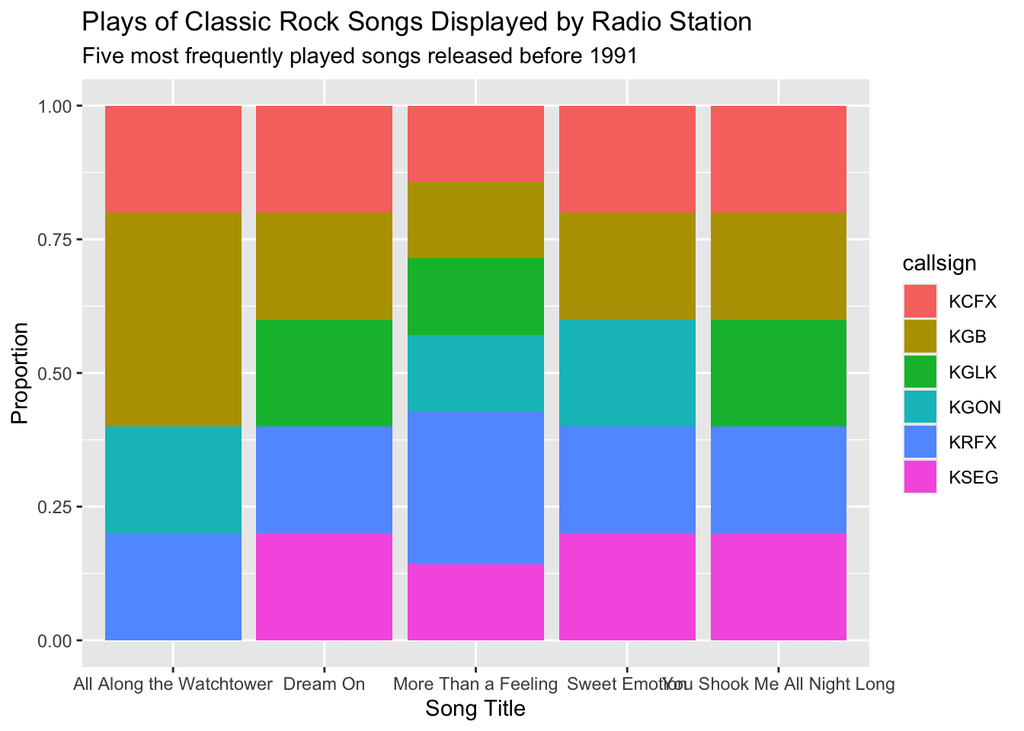

```r
#proportional bar chart of popular songs by proportion of plays from each radio.
ggplot(popularSongRadios, aes(x=song)) +geom_bar(aes(fill=callsign),position="fill") +labs(y="Proportion", x="Song Title",title = "Plays of Classic Rock Songs Displayed by Radio Station", subtitle = "Five most frequently played songs released before 1991")
```

### Great job! Today you learned how to wrangle multiple datasets using the ‘filter()’, ‘arrange()’, ‘slice()’, and ‘select()’ functions. You also created a custom proportional bar plot to illistruate your data.